# bayess

## Naive Bayes Classifier (GaussianNB)

**The Naive Bayes Classifier is a probabilistic algorithm based on applying Bayes' theorem with the assumption that features are independent given the class (this assumption is called "naive").**

**Strengths:**

- Fast and simple: Naive Bayes is computationally very efficient, making it well-suited for large datasets.
- Good for small datasets: It performs well even with small amounts of data.
- Handles categorical and continuous features: Gaussian Naive Bayes is effective for continuous data, while other variants (e.g., Bernoulli, Multinomial) can handle categorical data. **Weaknesses:**
- Strong independence assumption: The model assumes that features are conditionally independent, which is often unrealistic in real-world problems. This can limit its performance.
- Cannot model complex interactions: Due to its simplicity, it does not handle relationships between features, making it less effective on complex datasets. **Conclusions:** Naive Bayes works well for relatively simple problems and when the features are somewhat independent. It’s an excellent baseline model and performs well in cases like text classification (e.g., spam detection), but its performance drops in more complex scenarios where feature interactions matter.

```python
import numpy as np
import pandas as pd
from sklearn.model_selection import GridSearchCV
from sklearn.model_selection import train_test_split
from sklearn.preprocessing   import StandardScaler
from sklearn.naive_bayes import GaussianNB
from sklearn.datasets import load_iris
from sklearn.metrics import ConfusionMatrixDisplay, confusion_matrix
import matplotlib.pyplot as plt
from matplotlib.colors import ListedColormap
```

```python
# data preparaion
dataset = load_iris()
data = dataset.data
target = dataset.target

cols = dataset.feature_names
cols = [x[:-5].replace(' ','_') for x in cols]
df = pd.DataFrame(data=np.c_[data,target], columns=cols+['target'])
df.drop_duplicates(inplace=True)

X = df.copy()
y = X.pop('target')

scaler = StandardScaler()
scaler.fit(X)
X = scaler.transform(X)
X_train, X_test, y_train, y_test = train_test_split(X,y,test_size=0.2)


# Only the first two features (sepal length and sepal width) are used for simplicity in visualizing decision boundaries.
X_train = X_train[:, :2]
X_test = X_test[:, :2]
```

**Fitting a Naive Bayes classifier (GaussianNB) to the training data. Evaluating the classifier using the score function, which calculates the accuracy of the classifier on the test data.**

```python
# Naive Bayess classifier
model = GaussianNB()

model.fit(X_train,y_train)

r2 = model.score(X_test, y_test)

print("Bayess R2:", r2)
```

```
Bayess R2: 0.8333333333333334
```

```python
# Predict using the model
y_pred = model.predict(X_test)
```

## Plot decision Boundary

- Background Colors: The plot is divided into regions, each representing the classifier's prediction for that region. These regions are separated by the decision boundary, which is the line that separates the classes.
- Points: The points plotted over the background represent the training data. They are colored according to their true class, showing where they fall in the feature space.
- Points correctly classified by the model should be in the region corresponding to their class.
- Misclassified points will appear in a region that is colored differently from their true class.
- The decision boundary helps us understand how the model makes predictions and where it struggles.

**Interpretation:**

- If points are mostly on the correct side of the boundary, the model is performing well.
- If many points are on the wrong side of the boundary, this suggests that the classifier is misclassifying them.

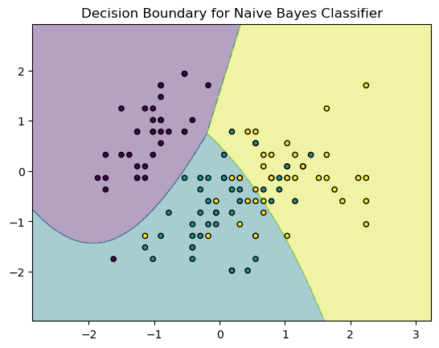

```python
def plot_decision_boundary(X, y, model, title="Decision Boundary"):
    x_min, x_max = X[:, 0].min() - 1, X[:, 0].max() + 1
    y_min, y_max = X[:, 1].min() - 1, X[:, 1].max() + 1
    xx, yy = np.meshgrid(np.arange(x_min, x_max, 0.01),
                         np.arange(y_min, y_max, 0.01))

    Z = model.predict(np.c_[xx.ravel(), yy.ravel()])
    Z = Z.reshape(xx.shape)

    # Corrected colors using shorthand notation
    plt.contourf(xx, yy, Z, alpha=0.4)
    plt.scatter(X[:, 0], X[:, 1], c=y, s=20, edgecolor='k')
    plt.title(title)
    plt.show()

plot_decision_boundary(X_train, y_train, model, title="Decision Boundary for Naive Bayes Classifier")
```

## Confusion Matrix:

**A confusion matrix is a table that helps visualize the performance of a classification model. The rows represent the actual classes, and the columns represent the predicted classes. A confusion matrix for 3 classes helps in visualizing how well the model is classifying multiple classes. The diagonal values represent correct predictions, while the off-diagonal values represent misclassifications.**

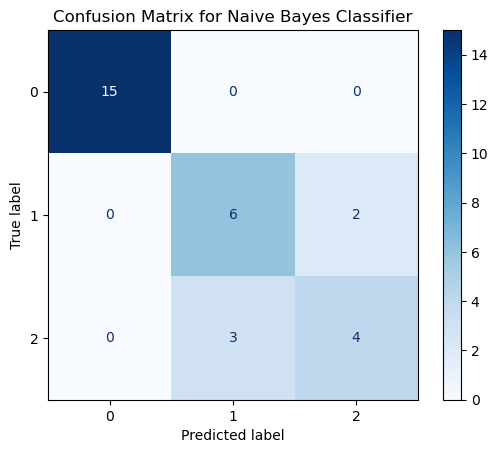

```python
# Create a confusion matrix plot
cm = confusion_matrix(y_test, y_pred)
disp = ConfusionMatrixDisplay(confusion_matrix=cm)
disp.plot(cmap='Blues')
plt.title('Confusion Matrix for Naive Bayes Classifier')
plt.show()
```